# fracdet quickstart

Constantino Antonio García Martínez

2016-08-07

## Introduction

**fracdet** is an R package implementing a simple, yet realistic, fractal-deterministic model that may be able to capture key features of complex systems with long term correlations. We assume that the observed signal $Y$ is the result of the superposition of a stochastic series $B$ and some band-limited deterministic signal $x$:

$$Y[n] = x[n] + B[n].$$

**fracdet** also provides a method that, under the assumptions of this model, permits the characterization of the fractal component and the estimation of the deterministic components of the system.

All the theoretical background is detailed in the paper:

> García, C.A., Otero, A., Félix, P., Presedo, J. & Márquez D.G., (2016). Simultaneous estimation of deterministic and fractal components in non-stationary time series (in review).

## The *waveletVar* class

According to a convenient modelling approach, long-memory signals can be studied as realizations of one of two classes of processes: fractional Gaussian noise (fGn) or fractional Brownian motion (fBm). Since the increments of a fBm signal yield a stationary fGn signal, we may focus on the fBm model. Thus, we assume that $B$ can be approximated by a fBm.

Two important features should be handled when analysing fBm signals: non-stationarity, which demands for a time-dependent analysis; and self-similarity, which demands for a scale-dependent analysis. Thus, wavelet analysis provides a proper framework for studying fBm signals. Furthermore, it is possible to estimate the fBm parameters by studying how the wavelet coefficients’ variance depend on the resolution level. *fracdet* provides the `waveletVar` class for studying the wavelet coefficients’ variances.

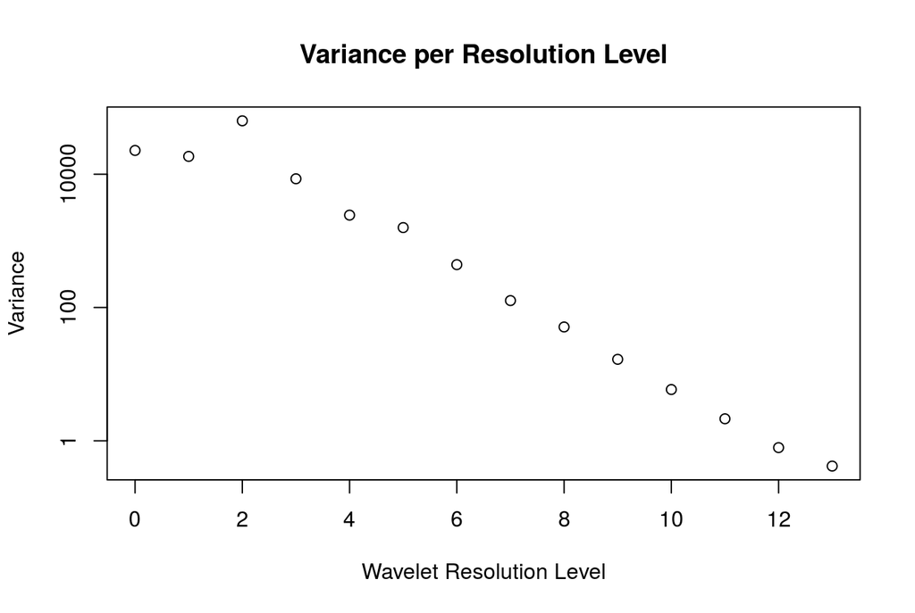

```r
library('fracdet')
# parameters for the example:
set.seed(3)
nlevels = 14
n = 2 ^ nlevels
H = 0.3
# Simulate a fbm and compute its wavelet transform.
b = fbmSim(n = n, H = H)
wb = wd(b, bc = "symmetric")
# Compute the wavelet coefficients variances and plot them.
vpr = waveletVar(wb)
plot(vpr)
```

## fBm parameter estimation

```r
model = estimateFbmPars(vpr,
                        use_resolution_levels = c(5:13))
# 'model' is a nls object and thus,
# we can obtain the parameter estimations with:
print(coef(model))
```

```
##         H    sigma2
## 0.2954949 1.0121385
```

## The *fracdet* class

What happens when our observed signal $Y$ may be approximated as $Y[n] = x[n] + B[n]$?

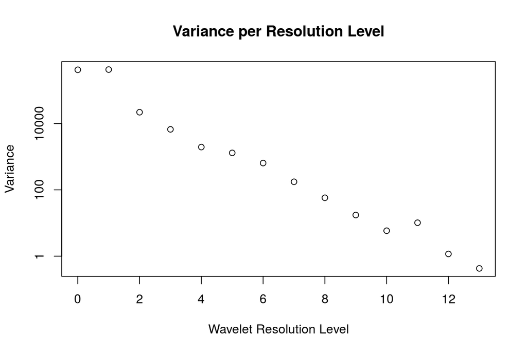

```r
# simulate a simple fbm + sinusal signal.
x = 1.5 * cospi(2 * 1:n / 10)
y = fbmSim(n = n, H = H) + x
wy = wd(y, bc = "symmetric")
# Compute the wavelet coefficients variances and plot them.
vpr = waveletVar(wy)
plot(vpr)
```

Can you see the deviations in the wavelet coefficients’ variance on level 11? This is due to the deterministic components. However, if the deterministic component $x$ is a band-limited signal we can still obtain good estimates of the fBm parameters.

```r
# Ignore resolution levels 11 and 12 to obtain the
# fBm parameters estimates.
model = estimateFbmPars(vpr,
                        use_resolution_levels = c(5:10,13))
```

The `fracdet` class can now be used to ease the procedure of working with a signal that may fulfil the assumptions of our fractal-deterministic model. The parameters required for the `fracdet` constructor are the wavelet transform of the observed signal, and the fitted-model object used for estimating the fBm parameters.

```r
# Create a fracdet object...
fd = fracdet(wy, model)
# ... and check the fbm parameters estimates.
print(coef(fd))
```

```
##         H    sigma2
## 0.3051759 1.0353774
```

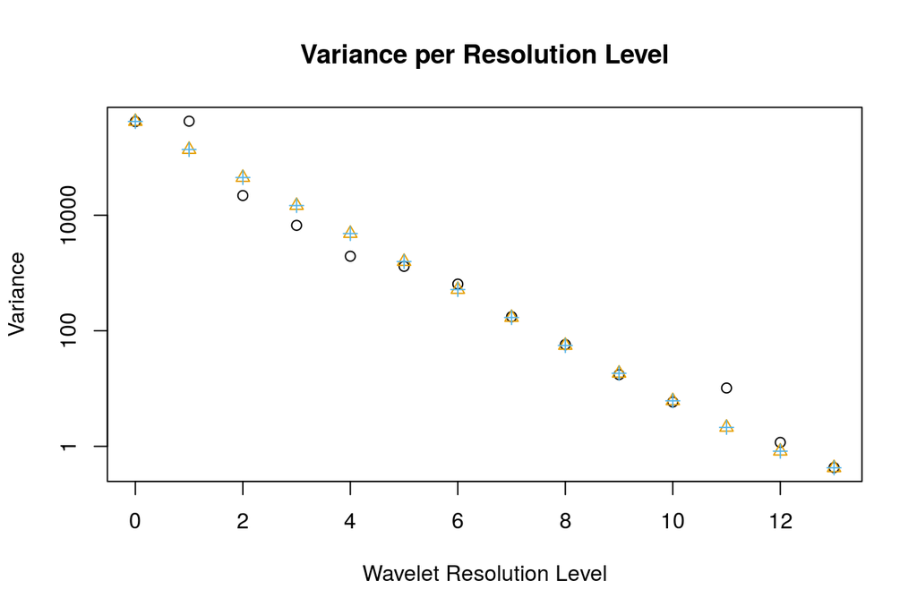

```r
# A plot of the fitted variances may also be useful.
plot(getWaveletVar(fd))
points(getFittedWaveletVar(fd),
       col = 2,
       pch = 2)
# we could also extract the nls-fit and use the predict function.
# The nls-fit is performed in semilog-space. Thus, a transformation
# of the predicted values is required.
nls_model = getWaveletVarModel(fd)
points(resolutionLevels(vpr),
       2 ^ predict(nls_model, newdata = data.frame(x = resolutionLevels(vpr))),
       col = 3,
       pch = 3)
```

By performing the nls-fit we have not only characterized the fBm process, but we have also gained information about the deterministic contributions in each wavelet resolution level. We shall use this information to obtain an estimation of the deterministic signal.

## Estimate the deterministic signal

Using all the available information about the observed signal, a bayesian model of the distribution of the deterministic and stochastic wavelet coefficients is built. The available information consist on:

- The estimates of the fBm parameters (which completely characterize the statistical properties of the fBm signal).
- The well-known statistical properties of the fBm signals in wavelet domain.
- The deviations from the theoretical wavelet coefficients’ variance permit the estimation of the energy distribution across the resolution levels of the deterministic signal.

The wavelet transform of the deterministic signal is then estimated by calculating the decision rule that minimizes the posterior expected value of a squared loss function. The `estimateDetSignal` implements all these actions and returns the estimate of the wavelet transform of the deterministic signal:

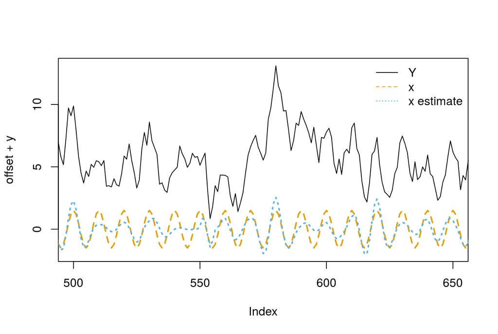

```r
# Estimate the deterministic signal (this may take a while) taking
# into account the deviations in level 11, 12.
wx = estimateDetSignal(fd, estimate_from = 11:12)
x_est = wr(wx)
# compare the original signal and the estimation
xlim = c(500, 650)
offset = 2
indx = xlim[[1]]:xlim[[2]]
ylim = range(c(offset + y[indx],
               x[indx],
               x_est[indx]))
plot(offset + y, xlim = xlim,
     ylim = ylim,
     type = "l")
lines(x, col = 2 , lty = 2, lwd = 2)
lines(x_est, col = 3, lty = 3, lwd = 2)
legend("topright", lty = 1:3, col = 1:3,
       legend = c("Y", "x", "x estimate"), bty = "n")
```